# Covid-19 data cleaning script

Mandip Farmahan

2023-05-05

## Import libraries

```r
library(tidyverse)
library(here)
library(tsibble)
```

## Import data files

```r
# Covid Hospital Admissions

hb_agesex <- read_csv(here("data/raw_data/covid_19/hospital_admissions_hb_agesex_20230504.csv"))
hb_specialty <- read_csv(here("data/raw_data/covid_19/hospital_admissions_hb_specialty_20230504.csv"))
hscp_agesex <- read_csv(here("data/raw_data/covid_19/hospital_admissions_hscp_agesex_20230504.csv"))
hscp_specialty <- read_csv(here("data/raw_data/covid_19/hospital_admissions_hscp_specialty_20230504.csv"))
```

```r
# Helper files

hb_names <- read_csv(here("data/raw_data/covid_19/health_board_names.csv")) %>%
  select(HB, HBName)
hscp_names<- read_csv(here("data/raw_data/covid_19/hscp_names.csv")) %>%
  select(HSCP, HSCPName, HB, HBName)
qualifier_info <- read_csv(here("data/raw_data/covid_19/qualifier_info.csv"))
```

```r
tibble_cv_admissions <- tibble(
  "hb_agesex" = names(hb_agesex),
  "hb_specialty" = c(names(hb_specialty), 1:2),
  "hscp_agesex" = c(names(hscp_agesex), ""),
  "hscp_specialty" = c(names(hscp_specialty), 1:3)
)
```

# Data Analysis

## Admissions By Health Board, Age and Sex

```r
head(hb_agesex)
```

```
## # A tibble: 6 × 12
##   WeekEnding HB        HBQF  AgeGr…¹ AgeGr…² Sex   SexQF Admis…³ Admis…⁴ Numbe…⁵
##        <dbl> <chr>     <chr> <chr>   <chr>   <chr> <chr> <chr>   <chr>     <dbl>
## 1   20200105 S08000015 <NA>  Under 5 <NA>    All   d     All     d            89
## 2   20200105 S08000015 <NA>  5 - 14  <NA>    All   d     All     d            26
## 3   20200105 S08000015 <NA>  15 - 44 <NA>    All   d     All     d           170
## 4   20200105 S08000015 <NA>  45 - 64 <NA>    All   d     All     d           247
## 5   20200105 S08000015 <NA>  65 - 74 <NA>    All   d     All     d           184
## 6   20200105 S08000015 <NA>  75 - 84 <NA>    All   d     All     d           169
## # … with 2 more variables: Average20182019 <dbl>, PercentVariation <dbl>, and
## #   abbreviated variable names ¹AgeGroup, ²AgeGroupQF, ³AdmissionType,
## #   ⁴AdmissionTypeQF, ⁵NumberAdmissions
```

```r
hb_agesex %>%
  filter(WeekEnding == 20200105,
         HB == "S08000015") %>%
  summarise(count = sum(NumberAdmissions, na.rm = TRUE))
```

```
## # A tibble: 1 × 1
##   count
##   <dbl>
## 1  5926
```

```r
hb_agesex %>%
  count(HB, HBQF)
```

```
## # A tibble: 16 × 3
##    HB        HBQF      n
##    <chr>     <chr> <int>
##  1 S08000015 <NA>   4659
##  2 S08000016 <NA>   4374
##  3 S08000017 <NA>   4755
##  4 S08000019 <NA>   5048
##  5 S08000020 <NA>   5134
##  6 S08000022 <NA>   4980
##  7 S08000024 <NA>   5187
##  8 S08000025 <NA>   2446
##  9 S08000026 <NA>   2380
## 10 S08000028 <NA>   3156
## 11 S08000029 <NA>   4792
## 12 S08000030 <NA>   5110
## 13 S08000031 <NA>   5190
## 14 S08000032 <NA>   4922
## 15 S92000003 d      5190
## 16 <NA>      <NA>   3171
```

```r
hb_agesex %>%
  count(AgeGroup, AgeGroupQF)
```

```
## # A tibble: 8 × 3
##   AgeGroup    AgeGroupQF     n
##   <chr>       <chr>      <int>
## 1 15 - 44     <NA>        6927
## 2 45 - 64     <NA>        7576
## 3 5 - 14      <NA>        5136
## 4 65 - 74     <NA>        7403
## 5 75 - 84     <NA>        7486
## 6 85 and over <NA>        6673
## 7 All ages    d          23742
## 8 Under 5     <NA>        5551
```

```r
hb_agesex %>%
  count(Sex, SexQF)
```

```
## # A tibble: 3 × 3
##   Sex    SexQF     n
##   <chr>  <chr> <int>
## 1 All    d     54804
## 2 Female <NA>   7809
## 3 Male   <NA>   7881
```

```r
hb_agesex %>%
  count(AdmissionType, AdmissionTypeQF)
```

```
## # A tibble: 3 × 3
##   AdmissionType AdmissionTypeQF     n
##   <chr>         <chr>           <int>
## 1 All           d               25806
## 2 Emergency     <NA>            24878
## 3 Planned       <NA>            19810
```

```r
hb_agesex_ts <- hb_agesex %>%
  mutate(year = year(ymd(WeekEnding)),
         month = month(ymd(WeekEnding)),
         .after = WeekEnding
  ) %>%
  mutate(AgeGroup = case_when(AgeGroup == "Under 5" ~ "0 - 05",
                              AgeGroup == "5 - 14" ~ "05 - 14",
                              TRUE ~ AgeGroup)) %>%
  mutate(pre_post_diff = NumberAdmissions - Average20182019) %>%
  left_join(hb_names, by = "HB")
```

### Age

Split by year (Weekly average number of admissions per year)

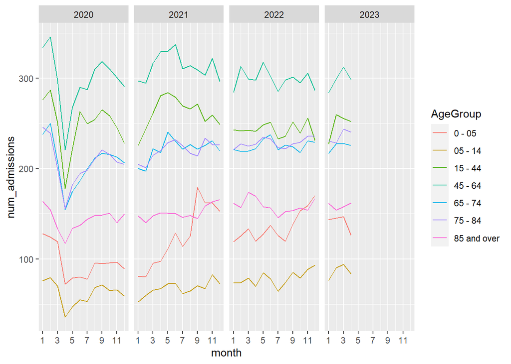

```r
# number of admissions-- MONTHLY CHECK FOR PATTERNS
hb_agesex_ts %>%
  filter(is.na(AgeGroupQF)) %>%
  group_by(AgeGroup, year, month) %>%
  summarise(num_admissions = mean(NumberAdmissions, na.rm = TRUE)) %>%
  ggplot(aes(x = month, y = num_admissions, colour = AgeGroup))+
  geom_line()+
  scale_x_continuous(breaks = c(1, 3, 5, 7, 9, 11))+
  facet_wrap(~ year, nrow = 1)
```

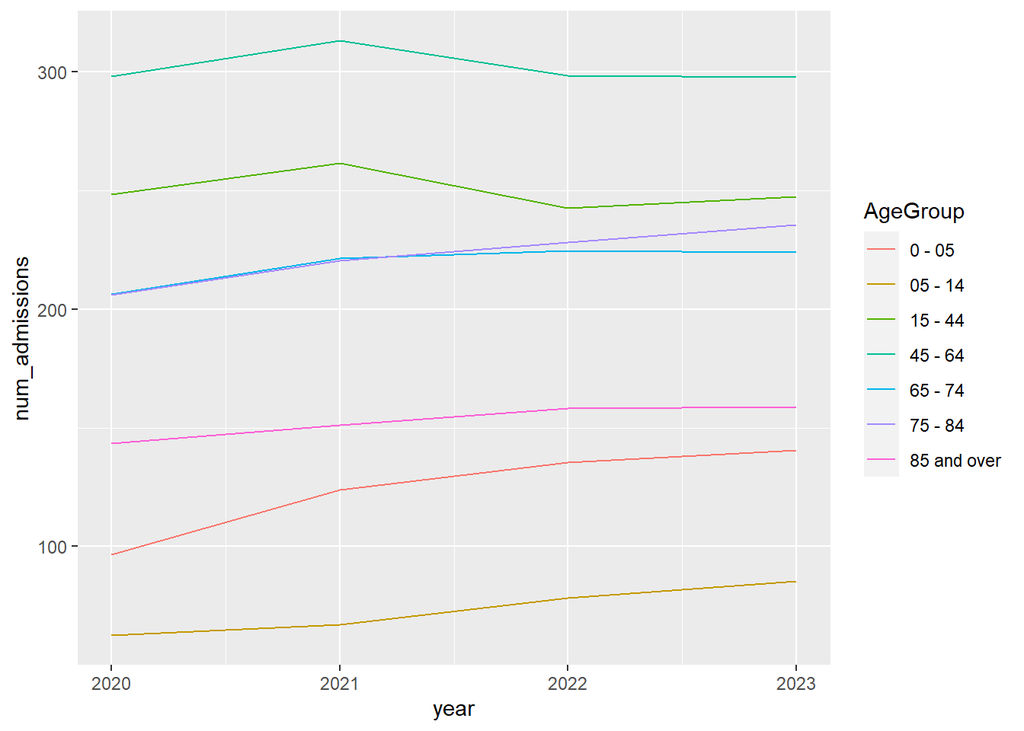

```r
# number of admissions
hb_agesex_ts %>%
  # filter(!is.na(HBName)) %>% # uncomment to include location
  filter(is.na(AgeGroupQF)) %>%
  group_by(AgeGroup, year) %>%
  summarise(num_admissions = mean(NumberAdmissions, na.rm = TRUE)) %>%
  ggplot(aes(x = year, y = num_admissions, colour = AgeGroup))+
  geom_line()
```

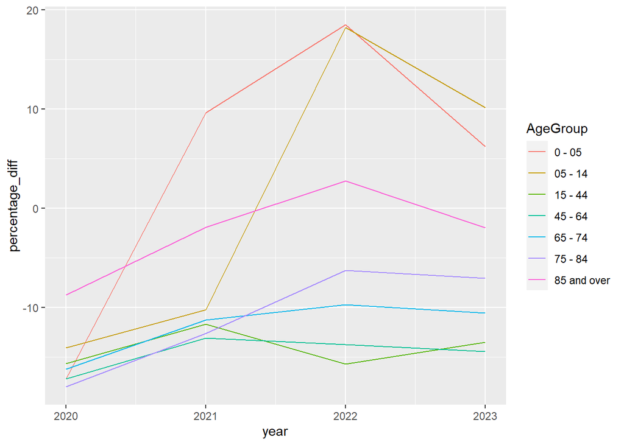

```r
# percentage difference from 2018/2019
hb_agesex_ts %>%
  # filter(!is.na(HBName)) %>% # uncomment to include location
  filter(is.na(AgeGroupQF)) %>%
  group_by(AgeGroup, year) %>%
  summarise(percentage_diff = mean(PercentVariation, na.rm = TRUE)) %>%
  ggplot(aes(x = year, y = percentage_diff, colour = AgeGroup))+
  geom_line()
```

### Gender

Split by year (Weekly average number of admissions per year)

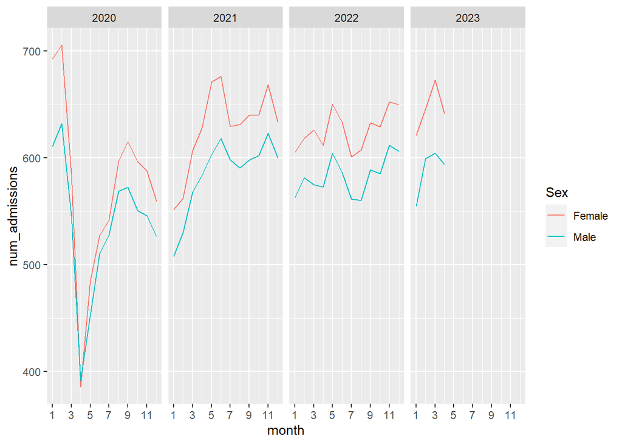

```r
# number of admissions -- MONTHLY CHECK FOR PATTERNS
hb_agesex_ts %>%
  filter(is.na(SexQF)) %>%
  group_by(Sex, year, month) %>%
  summarise(num_admissions = mean(NumberAdmissions, na.rm = TRUE)) %>%
  ggplot(aes(x = month, y = num_admissions, colour = Sex))+
  geom_line()+
  scale_x_continuous(breaks = c(1, 3, 5, 7, 9, 11))+
  facet_wrap(~ year, nrow = 1)
```

[output not shown]

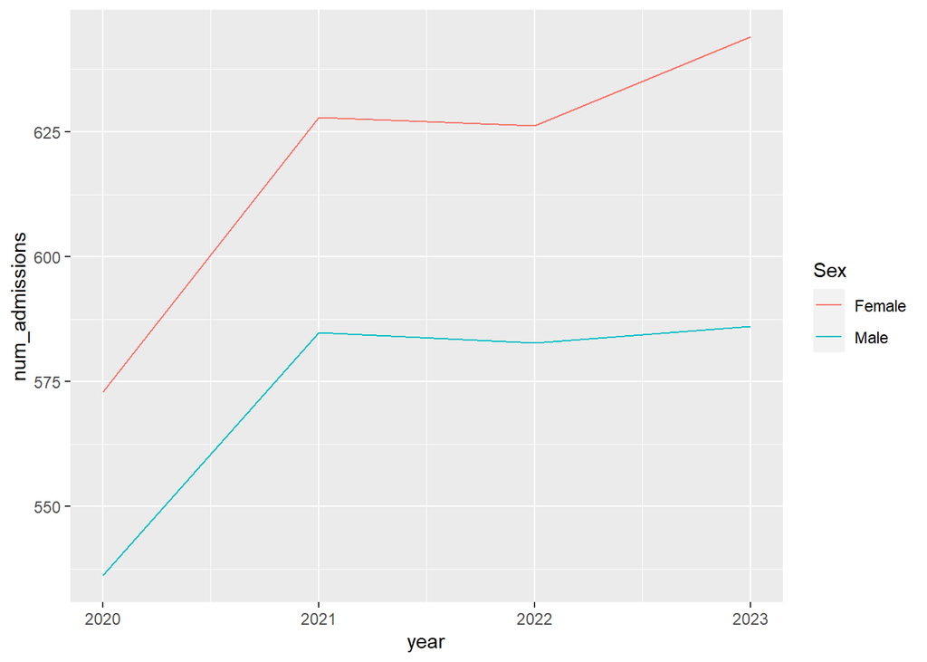

```r
# number of admissions
hb_agesex_ts %>%
  # filter(!is.na(HBName)) %>% # uncomment to include location
  filter(is.na(SexQF)) %>%
  group_by(Sex, year) %>%
  summarise(num_admissions = mean(NumberAdmissions, na.rm = TRUE)) %>%
  ggplot(aes(x = year, y = num_admissions, colour = Sex))+
  geom_line()
```

[output not shown]

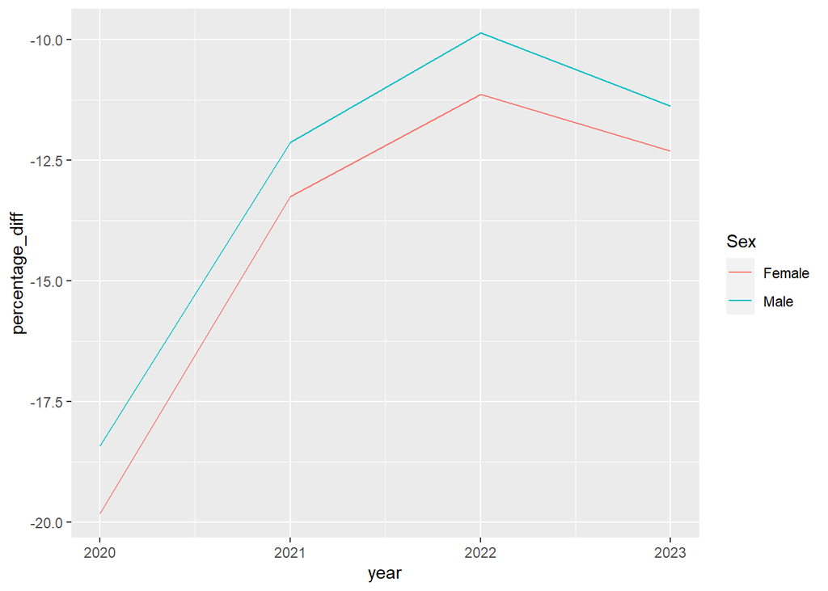

```r
# percentage difference from 2018/2019
hb_agesex_ts %>%
  # filter(!is.na(HBName)) %>% # uncomment to include location
  filter(is.na(SexQF)) %>%
  group_by(Sex, year) %>%
  summarise(percentage_diff = mean(PercentVariation, na.rm = TRUE)) %>%
  ggplot(aes(x = year, y = percentage_diff, colour = Sex))+
  geom_line()
```

The most notable data points are in April 2020 (huge dip), which I believe is when the news broke in the UK about covid as the cases first started being talked about in the media (March/April). I can’t remember if we were put into lock down but WFH definitely started then started then.

## Admissions By Health Board and Deprivation

file is empty

## Admissions By Health Board and Specialty

```r
head(hb_specialty)
```

```
## # A tibble: 6 × 10
##   WeekEnding HB    HBQF  Admis…¹ Admis…² Speci…³ Speci…⁴ Numbe…⁵ Avera…⁶ Perce…⁷
##        <dbl> <chr> <chr> <chr>   <chr>   <chr>   <chr>     <dbl>   <dbl>   <dbl>
## 1   20200105 S080… <NA>  All     d       Accide… <NA>         30    30.5    -1.6
## 2   20200105 S080… <NA>  All     d       All     d           991  1082      -8.4
## 3   20200105 S080… <NA>  All     d       Cardio… <NA>         17    11.5    47.8
## 4   20200105 S080… <NA>  All     d       Medica… <NA>        605   663      -8.7
## 5   20200105 S080… <NA>  All     d       Medica… <NA>        622   674.     -7.8
## 6   20200105 S080… <NA>  All     d       Paedia… <NA>        116   128.     -9.7
## # … with abbreviated variable names ¹AdmissionType, ²AdmissionTypeQF,
## #   ³Specialty, ⁴SpecialtyQF, ⁵NumberAdmissions, ⁶Average20182019,
## #   ⁷PercentVariation
```

```r
hb_specialty %>%
  filter(WeekEnding == 20200105,
         HB == "S08000015") %>%
  summarise(count = sum(NumberAdmissions, na.rm = TRUE))
```

```
## # A tibble: 1 × 1
##   count
##   <dbl>
## 1  5431
```

```r
hb_specialty %>%
  count(AdmissionType, AdmissionTypeQF)
```

```
## # A tibble: 3 × 3
##   AdmissionType AdmissionTypeQF     n
##   <chr>         <chr>           <int>
## 1 All           d               23518
## 2 Emergency     <NA>            22711
## 3 Planned       <NA>            16576
```

```r
hb_specialty %>%
  count(Specialty, SpecialtyQF)
```

```
## # A tibble: 13 × 3
##    Specialty                           SpecialtyQF     n
##    <chr>                               <chr>       <int>
##  1 Accident & Emergency                <NA>         2755
##  2 All                                 d            8052
##  3 Cancer                              <NA>         2623
##  4 Cardiology                          <NA>         5019
##  5 Community                           <NA>         3094
##  6 Gynaecology                         <NA>         4700
##  7 Medical (excl. Cardiology & Cancer) <NA>         7087
##  8 Medical (incl. Cardiology & Cancer) <NA>         7663
##  9 Paediatrics (medical & surgical)    <NA>         5646
## 10 Paediatrics (medical)               <NA>         5568
## 11 Paediatrics (surgical)              <NA>         1855
## 12 Surgery                             <NA>         7717
## 13 <NA>                                <NA>         1026
```

```r
hb_specialty_ts <- hb_specialty %>%
  mutate(year = year(ymd(WeekEnding)),
         month = month(ymd(WeekEnding)),
         .after = WeekEnding
  ) %>%
  mutate(pre_post_diff = NumberAdmissions - Average20182019) %>%
  left_join(hb_names, by = "HB")
```

[output not shown]

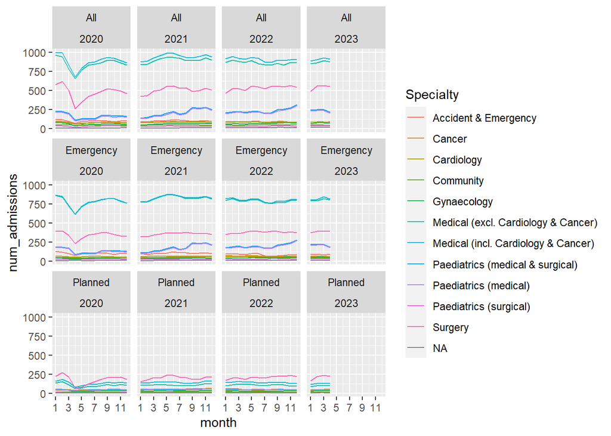

```r
# number of admissions-- MONTHLY CHECK FOR PATTERNS
hb_specialty_ts %>%
  filter(is.na(SpecialtyQF)) %>%
  group_by(Specialty, AdmissionType, year, month) %>%
  summarise(num_admissions = mean(NumberAdmissions, na.rm = TRUE)) %>%
  ggplot(aes(x = month, y = num_admissions, colour = Specialty))+
  geom_line()+
  scale_x_continuous(breaks = c(1, 3, 5, 7, 9, 11))+
  facet_wrap(AdmissionType ~ year)
```

[output not shown]

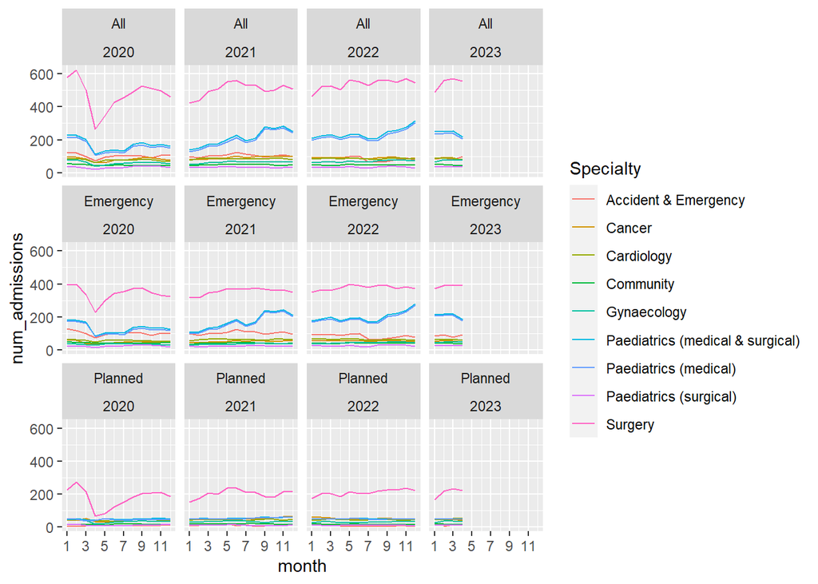

```r
# number of admissions-- MONTHLY CHECK FOR PATTERNS - remove generic specialty
hb_specialty_ts %>%
  filter(is.na(SpecialtyQF)) %>%
  filter(!is.na(Specialty),
         !str_detect(Specialty, "^Medical")) %>%
  group_by(Specialty, AdmissionType, year, month) %>%
  summarise(num_admissions = mean(NumberAdmissions, na.rm = TRUE)) %>%
  ggplot(aes(x = month, y = num_admissions, colour = Specialty))+
  geom_line()+
  scale_x_continuous(breaks = c(1, 3, 5, 7, 9, 11))+
  facet_wrap(AdmissionType ~ year)
```

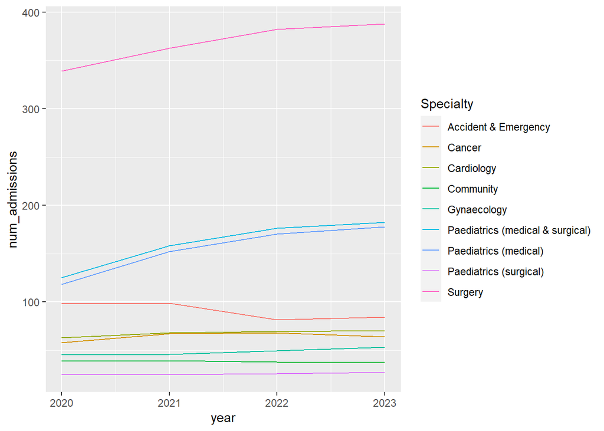

```r
# number of admissions
hb_specialty_ts %>%
  # filter(!is.na(HBName)) %>% # uncomment to include location
  filter(is.na(SpecialtyQF)) %>%
  filter(!is.na(Specialty), # remover NAs
         !str_detect(Specialty, "^Medical")) %>%
  group_by(Specialty, year) %>%
  summarise(num_admissions = mean(NumberAdmissions, na.rm = TRUE)) %>%
  ggplot(aes(x = year, y = num_admissions, colour = Specialty))+
  geom_line()
```

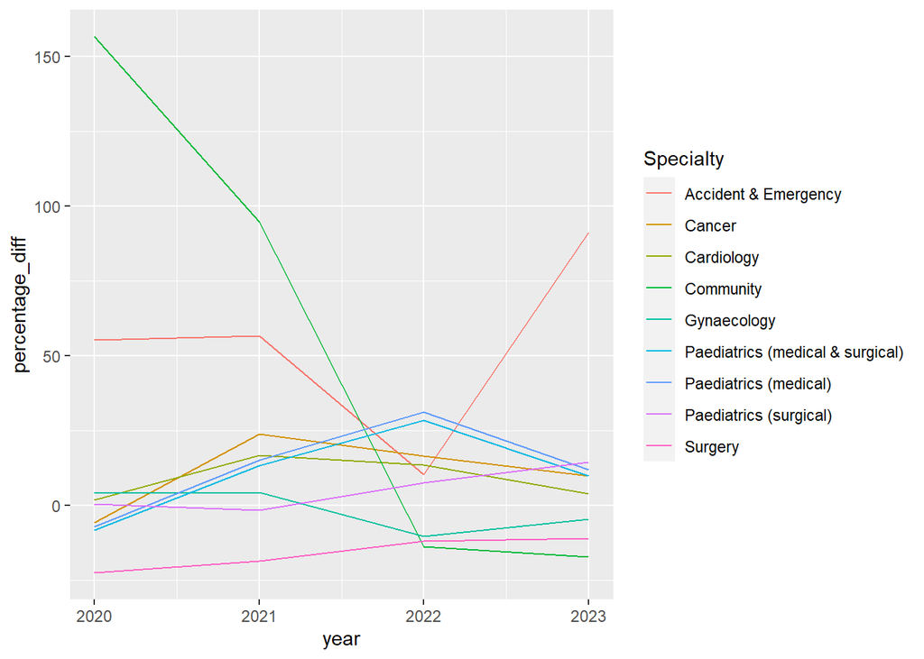

```r
# percentage difference from 2018/2019
hb_specialty_ts %>%
  # filter(!is.na(HBName)) %>% # uncomment to include location
  filter(is.na(SpecialtyQF)) %>%
  filter(!is.na(Specialty),  # remover NAs
         !str_detect(Specialty, "^Medical")) %>%
  group_by(Specialty, year) %>%
  summarise(percentage_diff = mean(PercentVariation, na.rm = TRUE)) %>%
  ggplot(aes(x = year, y = percentage_diff, colour = Specialty))+
  geom_line()
```

## Admissions By HSCP, Age and Sex

```r
head(hscp_agesex)
```

```
## # A tibble: 6 × 11
##   WeekEnding HSCP    AgeGr…¹ AgeGr…² Sex   SexQF Admis…³ Admis…⁴ Numbe…⁵ Avera…⁶
##        <dbl> <chr>   <chr>   <chr>   <chr> <chr> <chr>   <chr>     <dbl>   <dbl>
## 1   20200105 S37000… Under 5 <NA>    All   d     All     d            39    42
## 2   20200105 S37000… 5 - 14  <NA>    All   d     All     d            26    12
## 3   20200105 S37000… 15 - 44 <NA>    All   d     All     d            99    86
## 4   20200105 S37000… 45 - 64 <NA>    All   d     All     d           108   116.
## 5   20200105 S37000… 65 - 74 <NA>    All   d     All     d            71    65.5
## 6   20200105 S37000… 75 - 84 <NA>    All   d     All     d            68    85.5
## # … with 1 more variable: PercentVariation <dbl>, and abbreviated variable
## #   names ¹AgeGroup, ²AgeGroupQF, ³AdmissionType, ⁴AdmissionTypeQF,
## #   ⁵NumberAdmissions, ⁶Average20182019
```

```r
hscp_agesex %>%
  filter(WeekEnding == 20200105,
         HSCP == "S37000001") %>%
  summarise(count = sum(NumberAdmissions, na.rm = TRUE))
```

```
## # A tibble: 1 × 1
##   count
##   <dbl>
## 1  2783
```

```r
hscp_agesex_ts <- hscp_agesex %>%
  mutate(year = year(ymd(WeekEnding)),
         month = month(ymd(WeekEnding)),
         .after = WeekEnding
  ) %>%
  mutate(AgeGroup = case_when(AgeGroup == "Under 5" ~ "0 - 05",
                              AgeGroup == "5 - 14" ~ "05 - 14",
                              TRUE ~ AgeGroup)) %>%
  mutate(pre_post_diff = NumberAdmissions - Average20182019) %>%
  left_join(hscp_names, by = "HSCP")
```

### Age

Split by year (Weekly average number of admissions per year)

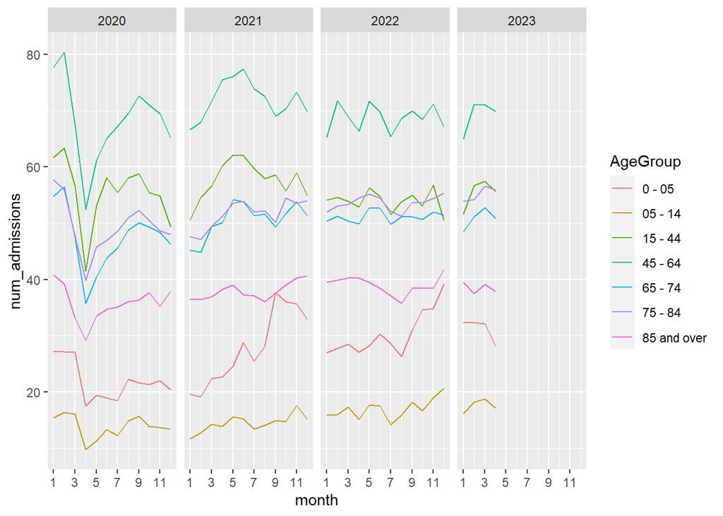

```r
# number of admissions-- MONTHLY CHECK FOR PATTERNS
hscp_agesex_ts %>%
  filter(is.na(AgeGroupQF)) %>%
  group_by(AgeGroup, year, month) %>%
  summarise(num_admissions = mean(NumberAdmissions, na.rm = TRUE)) %>%
  ggplot(aes(x = month, y = num_admissions, colour = AgeGroup))+
  geom_line()+
  scale_x_continuous(breaks = c(1, 3, 5, 7, 9, 11))+
  facet_wrap(~ year, nrow = 1)
```

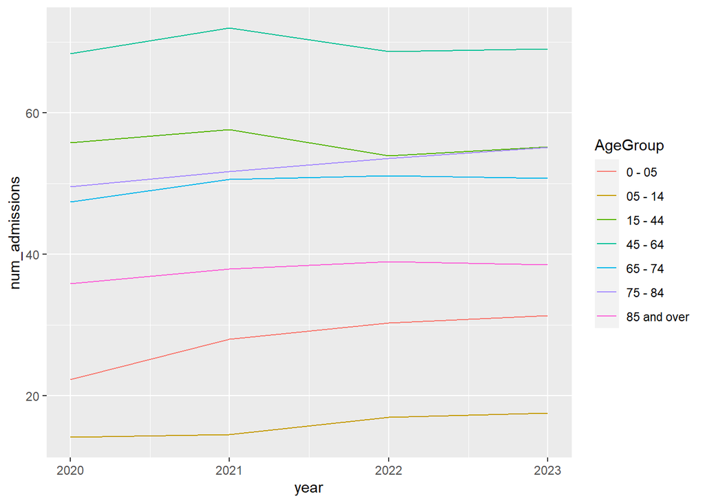

```r
# number of admissions
hscp_agesex_ts %>%
  # filter(!is.na(HSCPName)) %>% # uncomment to include location
  filter(is.na(AgeGroupQF)) %>%
  group_by(AgeGroup, year) %>%
  summarise(num_admissions = mean(NumberAdmissions, na.rm = TRUE)) %>%
  ggplot(aes(x = year, y = num_admissions, colour = AgeGroup))+
  geom_line()
```

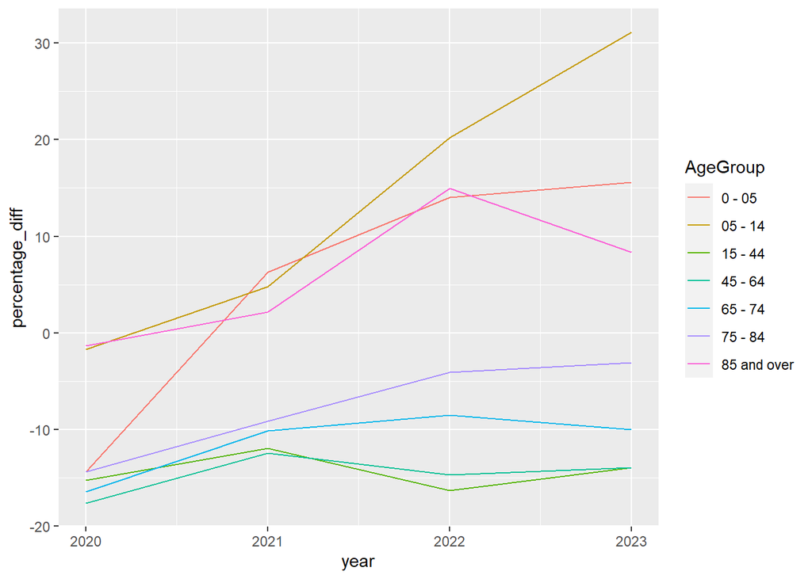

```r
# percentage difference from 2018/2019
hscp_agesex_ts %>%
  # filter(!is.na(HSCPName)) %>% # uncomment to include location
  filter(is.na(AgeGroupQF)) %>%
  group_by(AgeGroup, year) %>%
  summarise(percentage_diff = mean(PercentVariation, na.rm = TRUE)) %>%
  ggplot(aes(x = year, y = percentage_diff, colour = AgeGroup))+
  geom_line()
```

### Gender

Split by year (Weekly average number of admissions per year)

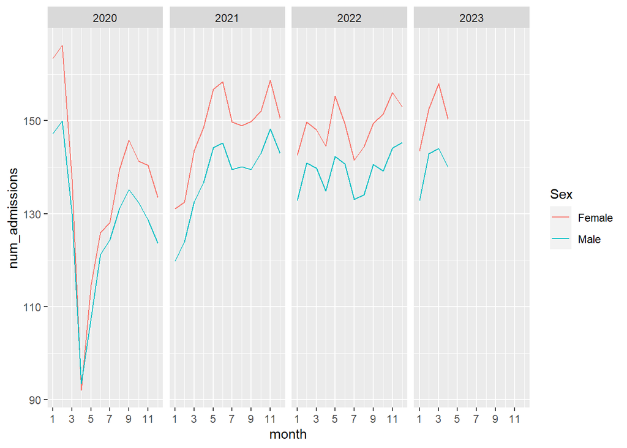

```r
# number of admissions -- MONTHLY CHECK FOR PATTERNS
hscp_agesex_ts %>%
  filter(is.na(SexQF)) %>%
  group_by(Sex, year, month) %>%
  summarise(num_admissions = mean(NumberAdmissions, na.rm = TRUE)) %>%
  ggplot(aes(x = month, y = num_admissions, colour = Sex))+
  geom_line()+
  scale_x_continuous(breaks = c(1, 3, 5, 7, 9, 11))+
  facet_wrap(~ year, nrow = 1)
```

[output not shown]

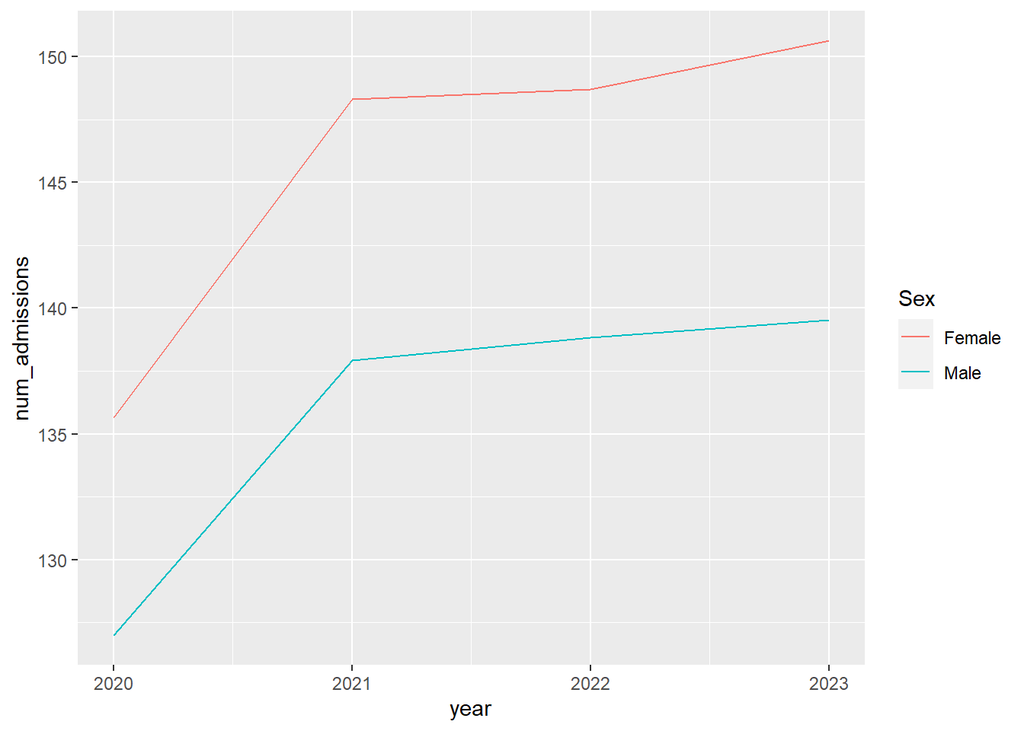

```r
# number of admissions
hscp_agesex_ts %>%
  # filter(!is.na(HSCPName)) %>% # uncomment to include location
  filter(is.na(SexQF)) %>%
  group_by(Sex, year) %>%
  summarise(num_admissions = mean(NumberAdmissions, na.rm = TRUE)) %>%
  ggplot(aes(x = year, y = num_admissions, colour = Sex))+
  geom_line()
```

[output not shown]

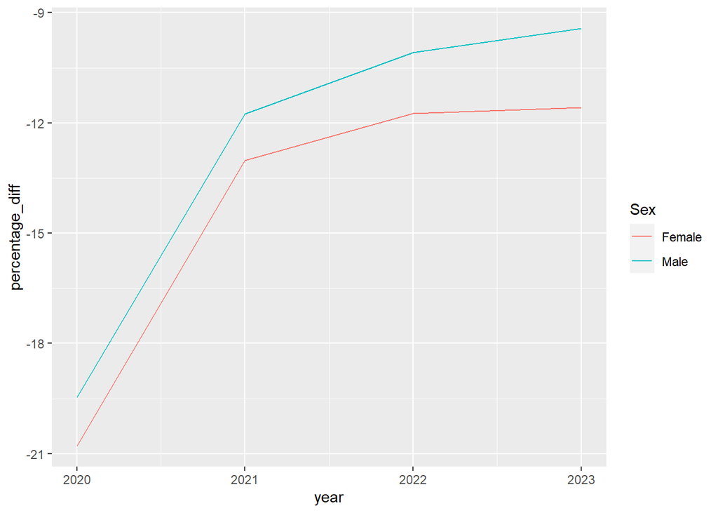

```r
# percentage difference from 2018/2019
hscp_agesex_ts %>%
  # filter(!is.na(HSCPName)) %>% # uncomment to include location
  filter(is.na(SexQF)) %>%
  group_by(Sex, year) %>%
  summarise(percentage_diff = mean(PercentVariation, na.rm = TRUE)) %>%
  ggplot(aes(x = year, y = percentage_diff, colour = Sex))+
  geom_line()
```

## Admissions By HSCP and Deprivation

file is empty

## Admissions By HSCP and Specialty

```r
head(hscp_specialty)
```

```
## # A tibble: 6 × 9
##   WeekEnding HSCP      Admissi…¹ Admis…² Speci…³ Speci…⁴ Numbe…⁵ Avera…⁶ Perce…⁷
##        <dbl> <chr>     <chr>     <chr>   <chr>   <chr>     <dbl>   <dbl>   <dbl>
## 1   20200105 S37000001 All       d       Accide… <NA>         23    16.5    39.4
## 2   20200105 S37000001 All       d       All     d           465   466      -0.2
## 3   20200105 S37000001 All       d       Cancer  <NA>         20    12      66.7
## 4   20200105 S37000001 All       d       Cardio… <NA>          7    15     -53.3
## 5   20200105 S37000001 All       d       Gynaec… <NA>         11     3.5   214.
## 6   20200105 S37000001 All       d       Medica… <NA>        223   232.     -4.1
## # … with abbreviated variable names ¹AdmissionType, ²AdmissionTypeQF,
## #   ³Specialty, ⁴SpecialtyQF, ⁵NumberAdmissions, ⁶Average20182019,
## #   ⁷PercentVariation
```

```r
hscp_specialty %>%
  filter(WeekEnding == 20200105,
         HSCP == "S37000001") %>%
  summarise(count = sum(NumberAdmissions, na.rm = TRUE))
```

```
## # A tibble: 1 × 1
##   count
##   <dbl>
## 1  2436
```

```r
hscp_specialty_ts <- hscp_specialty %>%
  mutate(year = year(ymd(WeekEnding)),
         month = month(ymd(WeekEnding)),
         .after = WeekEnding
  ) %>%
  mutate(pre_post_diff = NumberAdmissions - Average20182019) %>%
  left_join(hscp_names, by = "HSCP")
```

[output not shown]

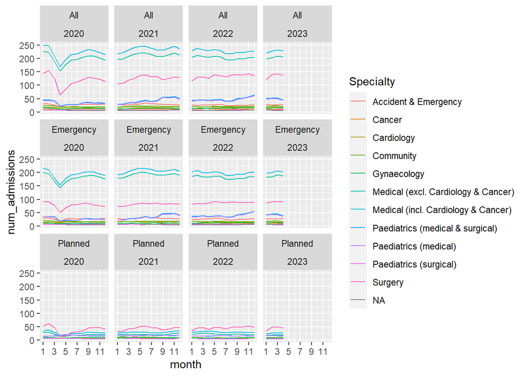

```r
# number of admissions-- MONTHLY CHECK FOR PATTERNS
hscp_specialty_ts %>%
  filter(is.na(SpecialtyQF)) %>%
  group_by(Specialty, AdmissionType, year, month) %>%
  summarise(num_admissions = mean(NumberAdmissions, na.rm = TRUE)) %>%
  ggplot(aes(x = month, y = num_admissions, colour = Specialty))+
  geom_line()+
  scale_x_continuous(breaks = c(1, 3, 5, 7, 9, 11))+
  facet_wrap(AdmissionType ~ year)
```

[output not shown]

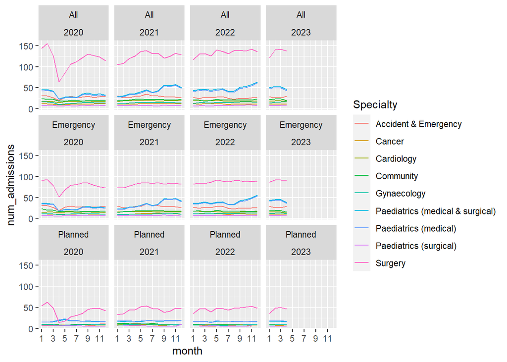

```r
# number of admissions-- MONTHLY CHECK FOR PATTERNS - remove generic specialty
hscp_specialty_ts %>%
  filter(is.na(SpecialtyQF)) %>%
  filter(!is.na(Specialty),
         !str_detect(Specialty, "^Medical")) %>%
  group_by(Specialty, AdmissionType, year, month) %>%
  summarise(num_admissions = mean(NumberAdmissions, na.rm = TRUE)) %>%
  ggplot(aes(x = month, y = num_admissions, colour = Specialty))+
  geom_line()+
  scale_x_continuous(breaks = c(1, 3, 5, 7, 9, 11))+
  facet_wrap(AdmissionType ~ year)
```

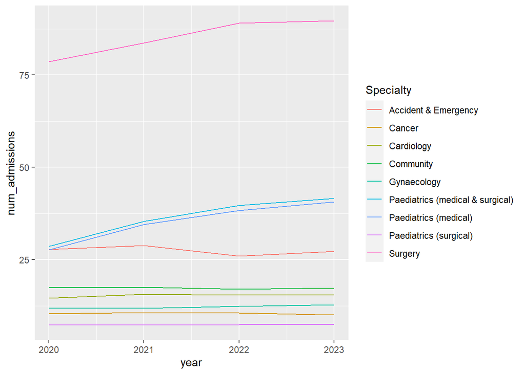

```r
# number of admissions
hscp_specialty_ts %>%
  # filter(!is.na(HSCPName)) %>% # uncomment to include location
  filter(is.na(SpecialtyQF)) %>%
  filter(!is.na(Specialty), # remover NAs
         !str_detect(Specialty, "^Medical")) %>%
  group_by(Specialty, year) %>%
  summarise(num_admissions = mean(NumberAdmissions, na.rm = TRUE)) %>%
  ggplot(aes(x = year, y = num_admissions, colour = Specialty))+
  geom_line()
```

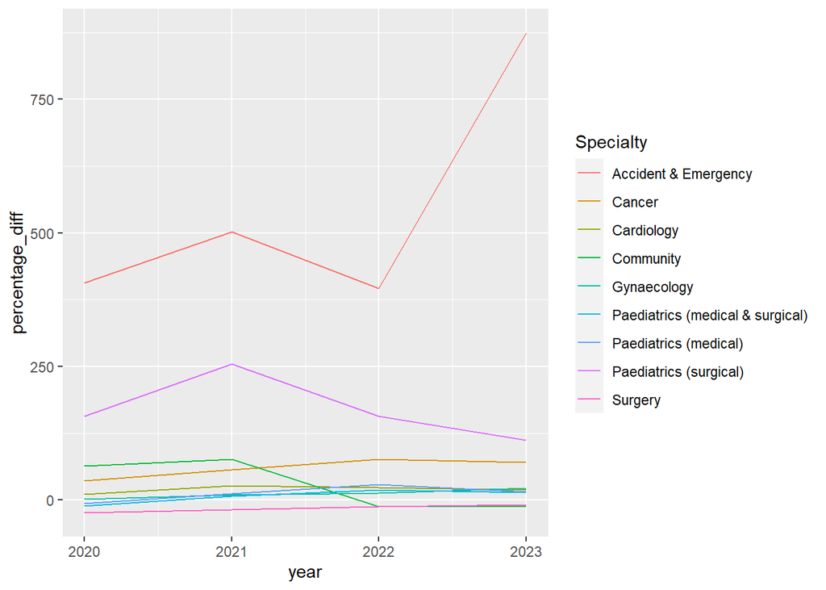

```r
# percentage difference from 2018/2019
hscp_specialty_ts %>%
  # filter(!is.na(HSCPName)) %>% # uncomment to include location
  filter(is.na(SpecialtyQF)) %>%
  filter(!is.na(Specialty),  # remover NAs
         !str_detect(Specialty, "^Medical")) %>%
  group_by(Specialty, year) %>%
  summarise(percentage_diff = mean(PercentVariation, na.rm = TRUE)) %>%
  ggplot(aes(x = year, y = percentage_diff, colour = Specialty))+
  geom_line()
```